# CSSA для одной строки

```r
rm(list=ls())
knitr::opts_chunk$set(
  echo = TRUE,
  message = FALSE,
  warning = FALSE,
  fig.width = 9,
  fig.height = 5
)

source("ssa-based methods/cssa-transform.r")

set.seed(1211)
```

Вспомогательные функции

```r
# Обрезаем значения до рабочего диапазона и зануляем совсем малые хвосты
clip01 <- function(m, low = 0.001, high = 0.99) {
  m <- as.matrix(m)
  m[!is.finite(m)] <- 0
  m[m < low] <- 0
  m[m > high] <- 1
  m
}
```

Тестовый пример.

```r
n <- 1000
signal_ind <- 10
sigma_noise <- 0.2
num_components_signal <- 1

clean_matrix <- matrix(0, nrow = 1, ncol = n)
clean_matrix[1, signal_ind] <- 1
noisy_matrix <- add.noise(clean_matrix, sigma = sigma_noise)


clean_row <- clean_matrix[1, ]
noisy_row <- noisy_matrix[1, ]

clean_dft_matrix <- dft(clean_matrix)
noisy_dft_matrix <- dft(noisy_matrix)

clean_dft <- clean_dft_matrix[1, ]
noisy_dft <- noisy_dft_matrix[1, ]

clean_fit <- ssa(clean_dft, kind = "cssa", svd.method = "svd")
noisy_fit <- ssa(noisy_dft, kind = "cssa", svd.method = "svd")
```

Смотрим на сигнал и сигнал с шумам

```r
old_par <- par(mfrow = c(2, 1), mar = c(3, 4, 3, 1))

plot(
  clean_row,
  type = "h",
  lwd = 3,
  col = "black",
  xlab = "Индекс",
  ylab = "Амплитуда",
  main = "Чистый сигнал"
)

plot(
  noisy_row,
  type = "h",
  lwd = 2,
  col = "grey30",
  xlab = "Индекс",
  ylab = "Амплитуда",
  main = "Та же строка после добавления шума"
)
```

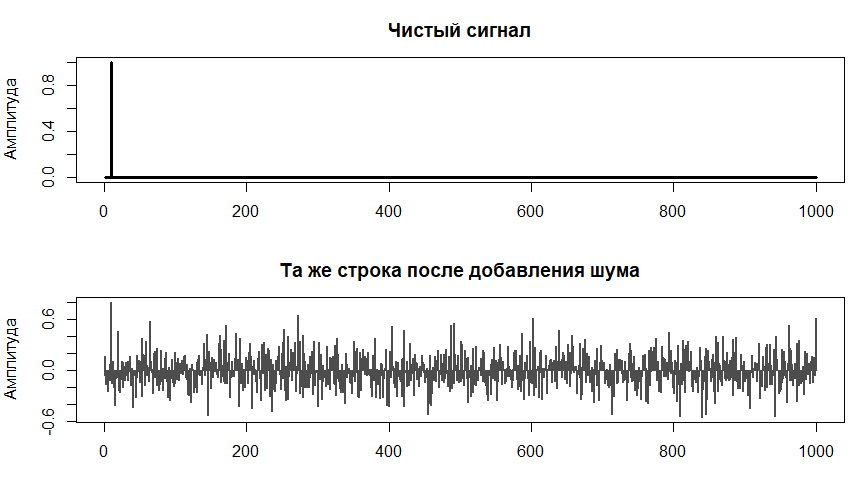

```r
par(old_par)
```

Смотрим на DFT всей строки, а именно: модуль и аргумент.

```r
old_par <- par(mfrow = c(2, 2), mar = c(3, 4, 3, 1))

plot(
  Mod(clean_dft),
  type = "h",
  lwd = 2,
  col = "black",
  xlab = "Частотный индекс",
  ylab = "|DFT|",
  main = "Чистая строка: модуль DFT"
)

plot(
  Arg(clean_dft),
  type = "l",
  lwd = 2,
  col = "black",
  xlab = "Частотный индекс",
  ylab = "arg(DFT)",
  main = "Чистая строка: фаза DFT"
)
```

```r
plot(
  Mod(noisy_dft),
  type = "h",
  lwd = 2,
  col = "grey30",
  xlab = "Частотный индекс",
  ylab = "|DFT|",
  main = "Шумная строка: модуль DFT"
)

plot(
  Arg(noisy_dft),
  type = "l",
  lwd = 2,
  col = "grey30",
  xlab = "Частотный индекс",
  ylab = "arg(DFT)",
  main = "Шумная строка: фаза DFT"
)
```

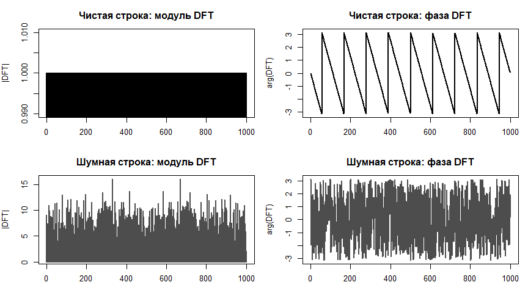

```r
par(old_par)
```

Сравниваем сингулярные значения для чистой и шумной строки Для чистого импульса ожидается практически ранг 1, а шум растягивает спектр.

```r
sigma_df <- data.frame(
  component = 1:12,
  clean = round(clean_fit$sigma[1:12], 6),
  noisy = round(noisy_fit$sigma[1:12], 6)
)

sigma_df
```

| component | clean | noisy |
| --- | --- | --- |
| 1 | 500.4998 | 432.0511 |
| 2 | 0.0000 | 377.1873 |
| 3 | 0.0000 | 366.1632 |
| 4 | 0.0000 | 359.7245 |
| 5 | 0.0000 | 350.2904 |
| 6 | 0.0000 | 337.5390 |
| 7 | 0.0000 | 324.9177 |
| 8 | 0.0000 | 324.4988 |
| 9 | 0.0000 | 316.5135 |
| 10 | 0.0000 | 314.2834 |

[output cut: 2 more lines]

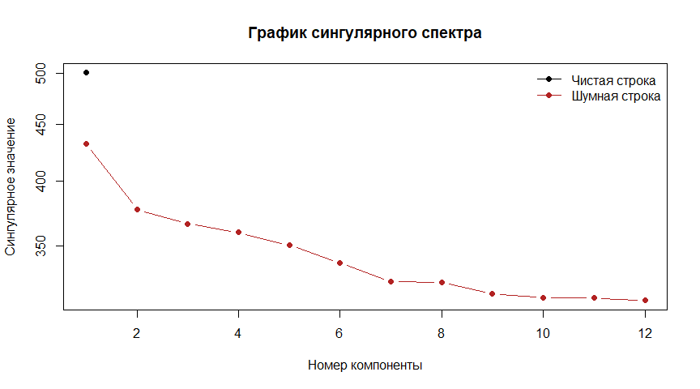

```r
matplot(
  sigma_df$component,
  sigma_df[, c("clean", "noisy")],
  type = "b",
  pch = 19,
  lty = 1,
  log = "y",
  col = c("black", "firebrick"),
  xlab = "Номер компоненты",
  ylab = "Сингулярное значение",
  main = "График сингулярного спектра"
)

legend(
  "topright",
  legend = c("Чистая строка", "Шумная строка"),
  col = c("black", "firebrick"),
  lty = 1,
  pch = 19,
  bty = "n"
)
```

Смотрим на левые сингулярные векторы `U` для шумной строки.

```r
# Отрисовка действительной и мнимой части
plot_complex_parts <- function(z, main_text) {
  plot(
    Re(z),
    type = "l",
    col = "steelblue",
    lwd = 2,
    xlab = "Индекс",
    ylab = "Значение",
    main = main_text
  )
  lines(Im(z), col = "firebrick", lwd = 2)
  legend(
    "topright",
    legend = c("Re", "Im"),
    col = c("steelblue", "firebrick"),
    lty = 1,
    bty = "n"
  )
}
```

**Замечание**. Для идеального сигнала $e_j$ его преобразование фурье – это точки на единичной окружности. Траекторная матрица имеет ранг 1 и собственный вектор для ненулевого собственного числа — это вектор, чьи компоненты тоже находятся на окружности. Если посмотреть вещественные и мнимые части, то это будут косинусы и синусы соответствующих углов. Для сравнения посмотрим на графики с зашумлением

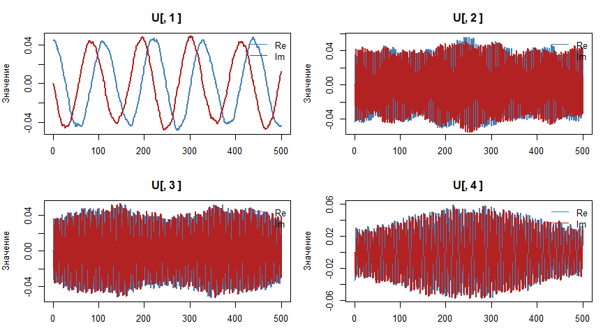

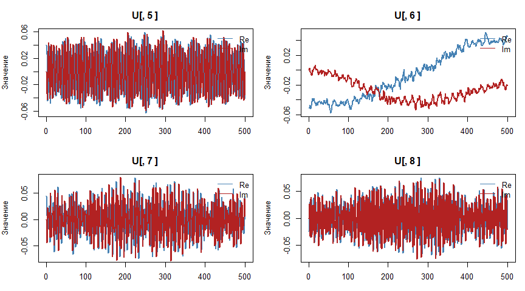

```r
old_par <- par(mfrow = c(2, 2), mar = c(3, 4, 3, 1))

for (j in 1:10) {
  plot_complex_parts(noisy_fit$U[, j], paste("U[,", j, "]"))
}
```

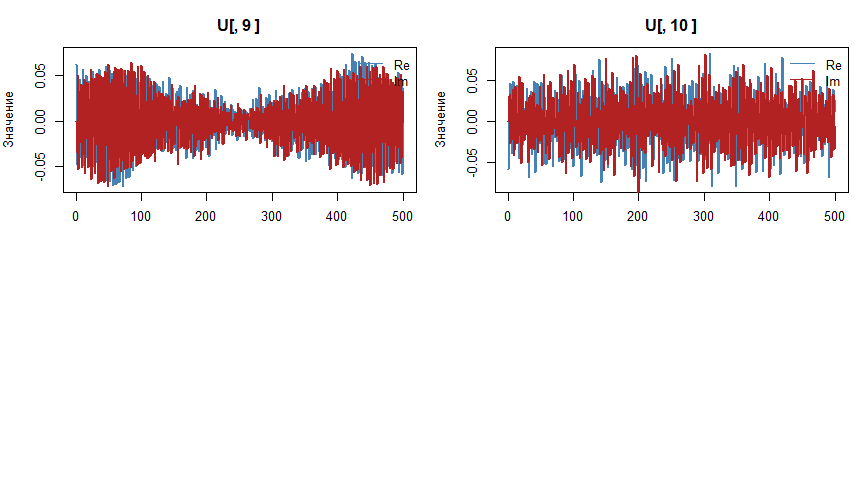

```r
par(old_par)
```

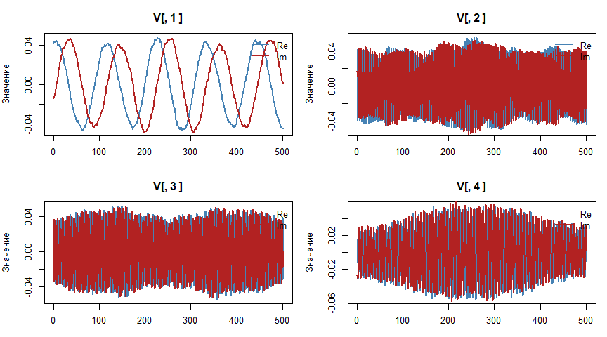

```r
old_par <- par(mfrow = c(2, 2), mar = c(3, 4, 3, 1))

for (j in 1:4) {
  plot_complex_parts(noisy_fit$V[, j], paste("V[,", j, "]"))
}

par(old_par)
```

Первую компоненту можно проинтерпретировать как то, о чем я написал выше. Остальное – шум. Но так бывает не всегда: ниже для координаты 500 показаны сингулярные векторы U покомпонентно:

```r
old_seed <- .Random.seed
signal_ind_center <- 500

center_clean_matrix <- matrix(0, nrow = 1, ncol = n)
center_clean_matrix[1, signal_ind_center] <- 1

set.seed(1211)
center_noisy_matrix <- add.noise(center_clean_matrix, sigma = sigma_noise)
.Random.seed <- old_seed

center_noisy_dft_matrix <- dft(center_noisy_matrix)
center_noisy_dft <- center_noisy_dft_matrix[1, ]
center_noisy_fit <- ssa(center_noisy_dft, kind = "cssa", svd.method = "svd")
```

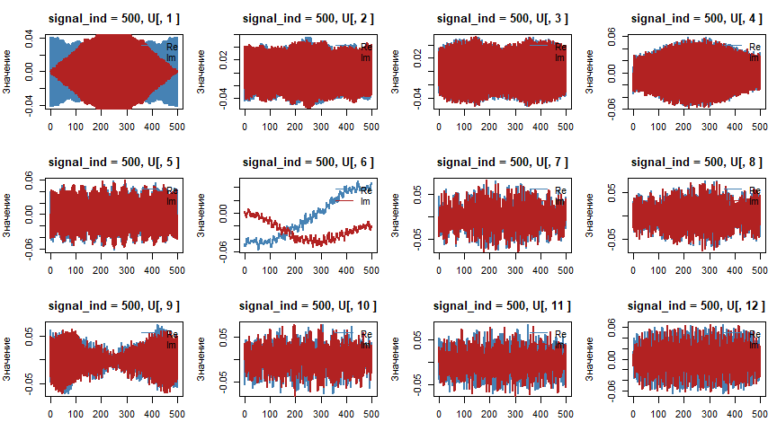

```r
old_par <- par(mfrow = c(3, 4), mar = c(3, 4, 3, 1))

for (j in 1:12) {
  plot_complex_parts(center_noisy_fit$U[, j], paste("signal_ind = 500, U[,", j, "]"))
}

par(old_par)
```

Для первых 4 выведем графики `Im~Re`

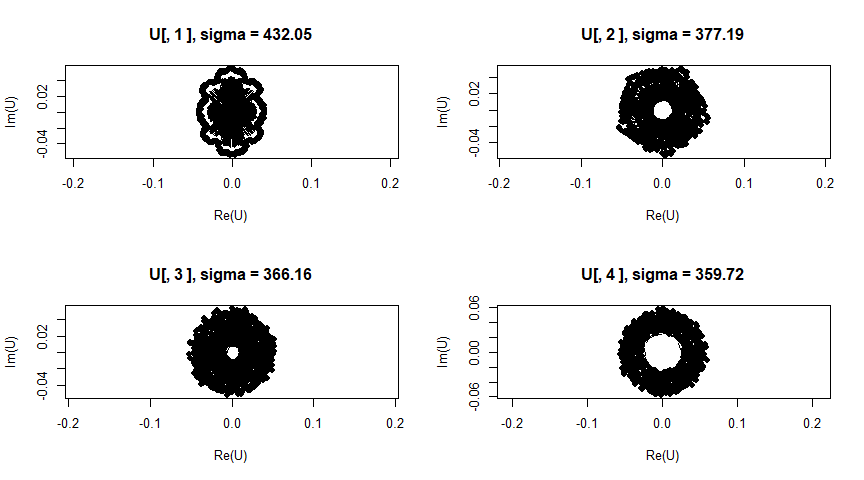

```r
idx <- 1:4

par(mfrow = c(2, 2))
for (i in idx) {
  u <- center_noisy_fit$U[, i]
  plot(
    u,
    type = "b",
    pch = 19,
    xlab = "Re(U)",
    ylab = "Im(U)",
    main = paste("U[,", i, "], sigma =", round(noisy_fit$sigma[i], 2) ) , asp=1
  )
}
```

Компонента с самым большим сингулярным числом не похожа на вектор комплексных эекспонент. Впрочем, результат все равно хороший:

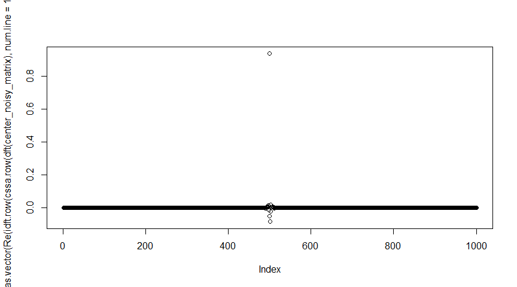

```r
center_noisy_matrix |> dft() |> cssa.row(num.line=1) |> idft.row() |> Re() |>as.vector() |> plot()
```

Cмотрим на реконструкцию в спектральной области по группам `1:k`, k=1,2,3,4.

```r
reconstruct_group <- function(fit, idx) {
  reconstruct(fit, groups = list(signal = idx))$signal
}

component_grid <- c(1, 2, 3, 4)

recon_dft_list <- setNames(
  lapply(component_grid, function(k) reconstruct_group(noisy_fit, 1:k)),
  paste0("k=", component_grid)
)

recon_matrix_list <- lapply(recon_dft_list, function(z) Re(idft.row(matrix(z, nrow = 1))))
recon_row_list <- lapply(recon_matrix_list, function(m) m[1, ])
recon_row_clipped <- lapply(recon_matrix_list, function(m) clip01(m)[1, ])
```

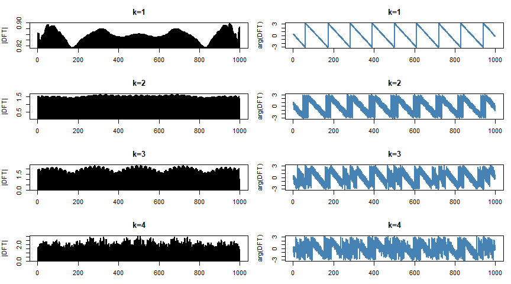

```r
old_par <- par(mfrow = c(4, 2), mar = c(3, 4, 3, 1))

for (nm in names(recon_dft_list)) {
  plot(
    Mod(recon_dft_list[[nm]]),
    type = "h",
    lwd = 2,
    col = "black",
    xlab = "Частотный индекс",
    ylab = "|DFT|",
    main = nm
  )

  plot(
    Arg(recon_dft_list[[nm]]),
    type = "l",
    lwd = 2,
    col = "steelblue",
    xlab = "Частотный индекс",
    ylab = "arg(DFT)",
    main = nm
  )
}

par(old_par)
```

Видно, что с одной лишь компонентой аргумент выглядит более-менее похожим на идеальный, хотя модуль DFT неоднородный(а в идеальном случае должен быть тождественным 1). Но это группировка `1:k`. Посмотрим на парный график собственных векторов.

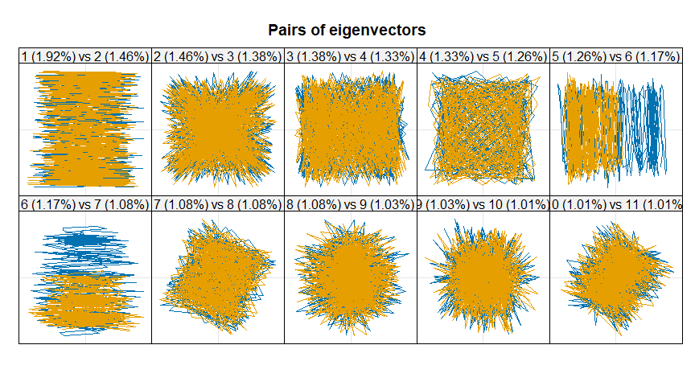

```r
plot(
  noisy_fit,
  type = "paired"
)
```

В теории, так как ранг 1, то никаких фигур по типу кругов/спиралей здесь отрисовываться не может.

**Но, возможно, есть то, чего я не вижу.**

График `Im~Re` для первых 12 собственных векторов.

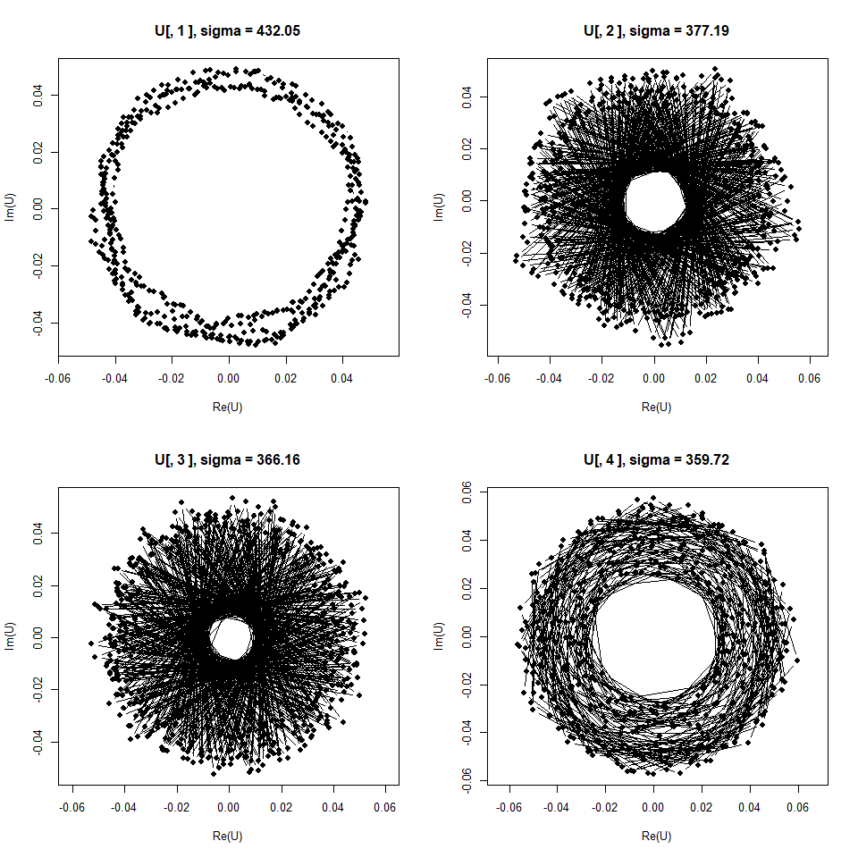

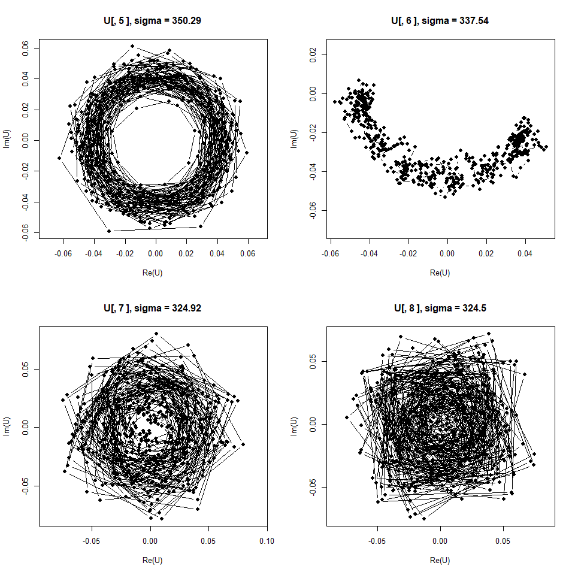

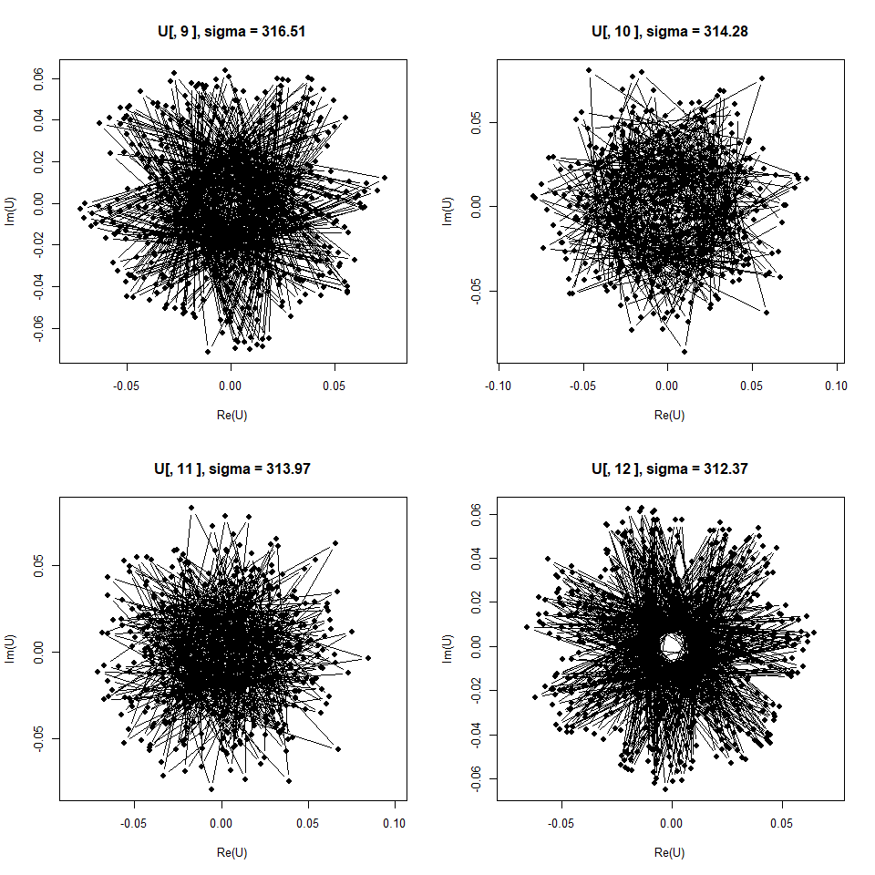

```r
idx <- 1:12

par(mfrow = c(2, 2))
for (i in idx) {
  u <- noisy_fit$U[, i]
  plot(
    u,
    type = "b",
    pch = 19,
    xlab = "Re(U)",
    ylab = "Im(U)",
    main = paste("U[,", i, "], sigma =", round(noisy_fit$sigma[i], 2) ) , asp=1
  )
}
```

```r
NA
NA
```

Идеальный случай – окружность, но многие векторы выводятся как толстые окружности, поэтому не понятно.

Оценка после `idft.row`:

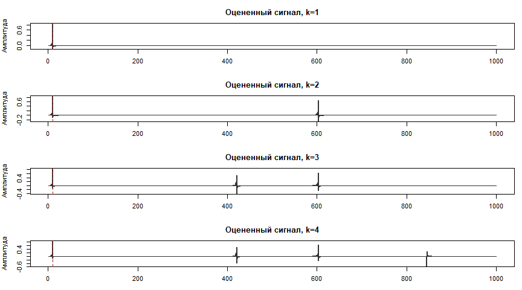

```r
old_par <- par(mfrow = c(4, 1), mar = c(3, 4, 3, 1))

for (nm in names(recon_row_list)) {
  plot(
    recon_row_list[[nm]],
    type = "h",
    lwd = 2,
    col = "grey20",
    xlab = "Индекс",
    ylab = "Амплитуда",
    main = paste("Оцененный сигнал,", nm)
  )
  abline(v = signal_ind, col = "firebrick", lty = 2)
}

par(old_par)
```

Далее выводим информацию о точках оцененного сигнала, которые не попали туда, куда мы хотели.

```r
tail_metrics <- function(x, signal_ind) {
  total_abs <- sum(abs(x))
  off_peak_abs <- sum(abs(x[-signal_ind]))

  data.frame(
    signal_ind = signal_ind,
    intensity = x[signal_ind],
    max_value = max(x),
    max_off_peak = max(abs(x[-signal_ind])),
    share = off_peak_abs / total_abs,
    positive_count = sum(x > 0)
  )
}

# Для набора порогов считаем, сколько значений остаются положительными.
threshold_table <- function(x, thresholds = c(0, 0.001, 0.01, 0.05, 0.1)) {
  data.frame(
    threshold = thresholds,
    count = vapply(thresholds, function(thr) sum(x > thr), numeric(1)),
    stringsAsFactors = FALSE
  )
}
```

```r
tail_summary_df <- do.call(
  rbind,
  list(
    clean = tail_metrics(clean_row, signal_ind),
    noisy = tail_metrics(noisy_row, signal_ind),
    recon_k1 = tail_metrics(recon_row_list$`k=1`, signal_ind),
    recon_k1_clipped = tail_metrics(recon_row_clipped$`k=1`, signal_ind)
  )
)

tail_summary_df$series <- rownames(tail_summary_df)
rownames(tail_summary_df) <- NULL
tail_summary_df <- tail_summary_df[, c("series", setdiff(names(tail_summary_df), "series"))]

tail_summary_df
```

| series | signal_ind | intensity | max_value | max_off_peak | share | positive_count |
| --- | --- | --- | --- | --- | --- | --- |
| clean | 10 | 1.0000000 | 1.0000000 | 0.00000000 | 0.0000000 | 1 |
| noisy | 10 | 0.8033001 | 0.8033001 | 0.64897364 | 0.9948661 | 465 |
| recon_k1 | 10 | 0.8401747 | 0.8401747 | 0.11407698 | 0.5689852 | 472 |
| recon_k1_clipped | 10 | 0.8401747 | 0.8401747 | 0.09704223 | 0.3401651 | 84 |

Посмотрим, сколько остается ненулевых элементов при разном пороговании

```r
threshold_df <- data.frame(
  threshold = c(0, 0.001, 0.01, 0.05, 0.1),
  recon_k1 = threshold_table(recon_row_list$`k=1`)$count,
  recon_k1_clipped = threshold_table(recon_row_clipped$`k=1`)$count
)

threshold_df
```

| threshold | recon_k1 | recon_k1_clipped |
| --- | --- | --- |
| 0.000 | 472 | 84 |
| 0.001 | 84 | 84 |
| 0.010 | 5 | 5 |
| 0.050 | 2 | 2 |
| 0.100 | 1 | 1 |

### Важно

В этом чанке я попытался найти индексы(хотя бы 1) для фиксированного шума, для которых оценка дает не тот результат, то есть максимум достигается не в изначальном месте.

Это тот самый случай когда на матрице 100 на 100 некоторые пиксели отклонялись от линии прямой.

Здесь написан весь код(то есть полный проход по всем индексам и тп), но я поменял начальный индекс с 1 до 40, чтобы долго не ждать, ведь я знаю, на каком индексе будет ошибка.

```r
set.seed(1211)
fixed_noise_matrix <- add.noise(matrix(0, nrow = 1, ncol = n), sigma = sigma_noise)

build_fixed_noise_case <- function(signal_ind, noise_matrix) {
  clean_matrix <- matrix(0, nrow = 1, ncol = n)
  clean_matrix[1, signal_ind] <- 1

  noisy_matrix <- clean_matrix + noise_matrix
  noisy_dft_matrix <- dft(noisy_matrix)
  noisy_fit <- ssa(noisy_dft_matrix[1, ], kind = "cssa", svd.method = "svd")

  est <- noisy_dft_matrix |>
    cssa.row(num.line = num_components_signal) |>
    idft.row() |>
    Re()

  est <- as.numeric(est[1, ])

  list(
    signal_ind = signal_ind,
    max_ind = which.max(est),
    clean_matrix = clean_matrix,
    noisy_matrix = noisy_matrix,
    noisy_dft_matrix = noisy_dft_matrix,
    fit = noisy_fit,
    est = est
  )
}

bad_case <- NULL
for (candidate_signal_ind in 40:n) {
  candidate_case <- build_fixed_noise_case(candidate_signal_ind, fixed_noise_matrix)

  if (candidate_case$max_ind != candidate_case$signal_ind) {
    bad_case <- candidate_case
    break
  }
}

noise_only_dft_matrix <- dft(fixed_noise_matrix)
noise_only_fit <- ssa(noise_only_dft_matrix[1, ], kind = "cssa", svd.method = "svd")
noise_only_est <- noise_only_dft_matrix |>
  cssa.row(num.line = num_components_signal) |>
  idft.row() |>
  Re()
noise_only_est <- as.numeric(noise_only_est[1, ])
noise_only_max_ind <- which.max(noise_only_est)

bad_case_summary <- data.frame(
  signal_ind = bad_case$signal_ind,
  max_ind = bad_case$max_ind,
  noise_only_max_ind = noise_only_max_ind,
  signal_value = bad_case$est[bad_case$signal_ind],
  max_value = bad_case$est[bad_case$max_ind],
  noise_only_max_value = noise_only_est[noise_only_max_ind]
)

bad_case_summary
```

| signal_ind | max_ind | noise_only_max_ind | signal_value | max_value | noise_only_max_value |
| --- | --- | --- | --- | --- | --- |
| 41 | 603 | 603 | 3.365464e-07 | 0.6438494 | 0.6438604 |

```r
sigma_compare_df <- data.frame(
  component = 1:12,
  bad_case = round(bad_case$fit$sigma[1:12], 6),
  noise_only = round(noise_only_fit$sigma[1:12], 6)
)

sigma_compare_df
```

| component | bad_case | noise_only |
| --- | --- | --- |
| 1 | 377.1909 | 377.1897 |
| 2 | 366.1691 | 366.1644 |
| 3 | 359.7379 | 359.7357 |
| 4 | 350.5501 | 350.2940 |
| 5 | 346.9313 | 337.5454 |
| 6 | 337.3802 | 324.9191 |
| 7 | 324.8820 | 324.4990 |
| 8 | 324.4969 | 316.5144 |
| 9 | 316.5090 | 314.2873 |
| 10 | 314.2816 | 313.9703 |

[output cut: 2 more lines]

```r
old_par <- par(mfrow = c(2, 2), mar = c(3, 4, 3, 1))

plot(
  bad_case$est,
  type = "h",
  lwd = 2,
  col = "grey20",
  xlab = "Индекс",
  ylab = "Амплитуда",
  main = paste("Плохой случай:", bad_case$signal_ind, "->", bad_case$max_ind)
)
abline(v = bad_case$signal_ind, col = "firebrick", lty = 2)
```

```r
abline(v = bad_case$max_ind, col = "steelblue", lty = 2)

plot(
  noise_only_est,
  type = "h",
  lwd = 2,
  col = "grey20",
  xlab = "Индекс",
  ylab = "Амплитуда",
  main = paste("Тот же шум без сигнала:", noise_only_max_ind)
)
```

```r
abline(v = noise_only_max_ind, col = "steelblue", lty = 2)

plot_complex_parts(bad_case$fit$U[, 1], "bad case: U[, 1]")
```

```r
plot_complex_parts(noise_only_fit$U[, 1], "noise only: U[, 1]")

par(old_par)
```

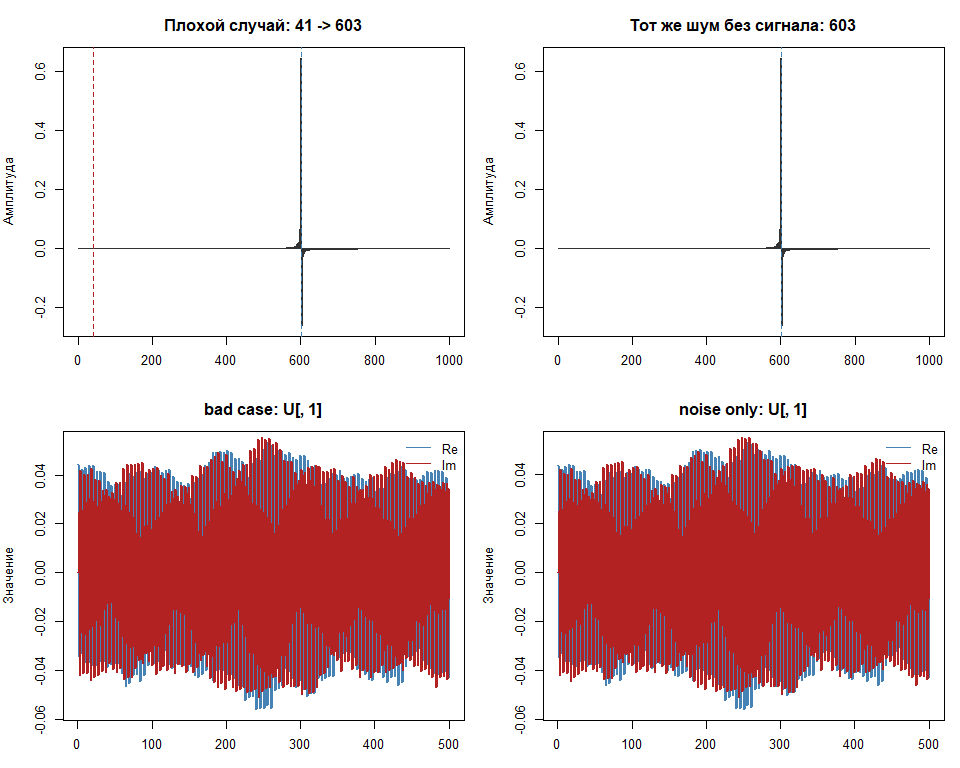

```r
old_par <- par(mfrow = c(3, 4), mar = c(3, 4, 3, 1))
```

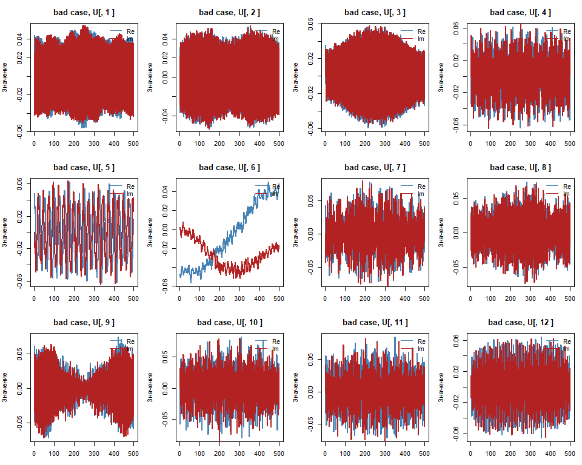

```r
for (j in 1:12) {
  plot_complex_parts(
    bad_case$fit$U[, j],
    paste("bad case, U[,", j, "]")
  )
}

par(old_par)
```

```r
NA
NA
```

Выбрали номер `index=41`. Итого, реконструкция дала не тот результат, потому что формально выбиралась компонента с наибольшим сингулярным числом. При этом я заметил знакомые синусоиды на векторе номер 5. Попробуем реконструировать по нему:

```r
rec5 <- Rssa::reconstruct(
  bad_case$fit,
  groups = list(Seasonality = 5)
)$Seasonality

row5 <- rec5 |>
  matrix(nrow = 1) |>
  idft.row() |>
  Re()

row5 <- as.numeric(row5[1, ])

which.max(row5)
```

```
[1] 41
```

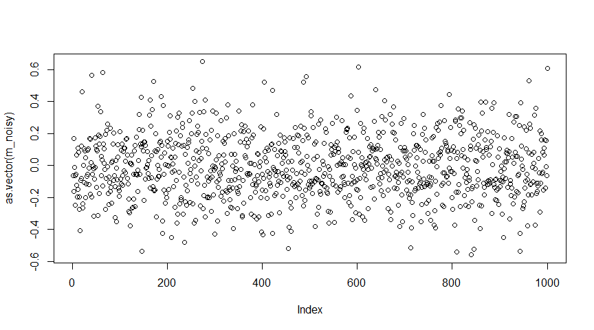

```r
m <- matrix(0, 1, 1000)
m[41] <- 1
m_noisy <- m + fixed_noise_matrix


m_noisy |> as.vector() |> plot()
```

Выводы: - Плохая с точки зрения преобразования Хафа локализация непонятно как решается, если, конечно, не учитывать обычный фильтр по порогу(фиксированный или квантильный). - Точки выбиваются из-за неправильного выбора компонент в реконструкции.